梁时婧 11712638

# Assignment 2

```python
import math
import numpy as np
import pandas as pd
import xarray as xr
import matplotlib.pyplot as plt
from matplotlib import ticker, cm
from scipy.optimize import curve_fit
```

## Question 1

**Mars is 2.3e8 km away from the Sun; its albedo is 0.15. Its only source of heat is solar radiation.**

**(a) Calculate the effective temperature of Mars.**

Total radiation from the Sun's surface $E_S = 4\pi R_S^2\sigma T_S^4$

Radiation flux reaching at the Mar's TOA: $F_S = \frac{E_s}{4\pi d^2}$, d is the Sun-Mars distance

According to the radiative balance, $\sigma T_M^4 = \frac{Fs(1-A)}{4}$

The effective temperature on Mars is calculated: $T_M = 215.4 K$

```python
Es = 4*math.pi*((6.955e8)**2)*(5.67e-8)*(5770**4) # Unit: W

# Solar constant on Mars
Fs = Es/(4*math.pi*(2.3e11)**2) # irradiance W m-2

Tm = (Fs*(1-0.15)/(4*(5.67e-8)))**(1/4)
Tm # Effective temperature on Mars. Unit K
```

```
215.42703091820076
```

**(b) The temperature observed at the surface of Mars is 220 K. What do you conclude about the Martian atmosphere?**

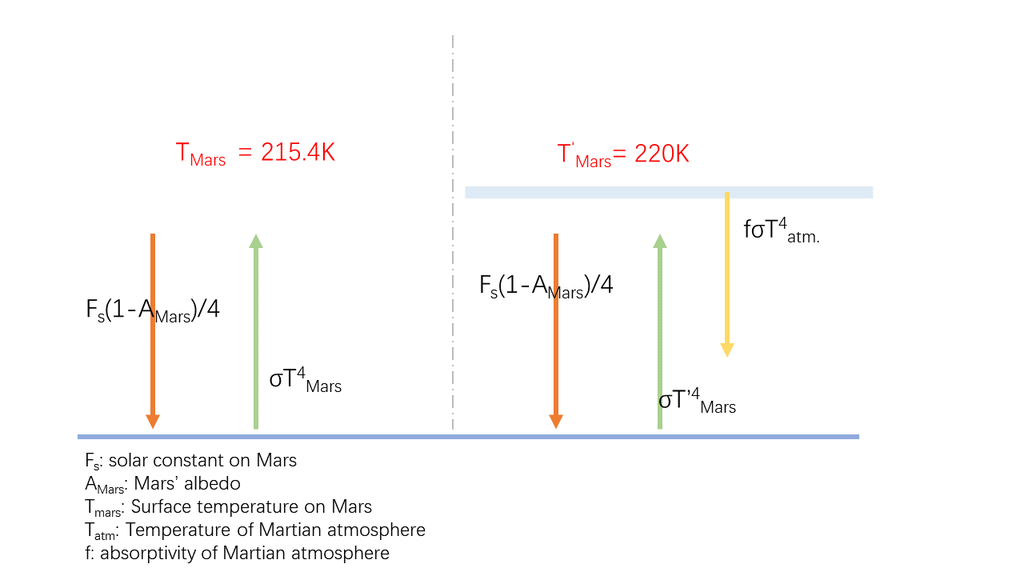

(1) Some greenhouse gases exit in the Martian atmoshpere and act to absorb the infared radiation. This is because the observed temperature is higher than the effective temperature.

(2) The atmohsphere on Mars is very thin. The difference between the observed temperature and effective temperature is small. According to the radiative balance, the downward radiation contributed by this thin atmoshpere can lead to a slightly increase in Martian surface temperature. Furthermore, the thin atmoshphere only contributes a small amount of incoming longwave radiaion to the surface. So the observed temperature is still close to the effective temperature numerically.

## Question 2

**The Earth's effective temperature during distant past may be much lower than the current value. This is because the Sun's radiation during its early years may be 30% weaker than what it is now. Assuming that the distance between the Sun and the Earth has not changed significantly since the time of the Earth's formation 4.6 billion years ago.**

**Use python to make a 2-D contour plot of the Earth's effective temperature (Te) for a range of solar constants and a range of albedos.**

Calculating the solar constant on the Earth: $E_S = 4\pi R_S^2\sigma T_S^4$

Radiation flux reaching at the Earth's TOA: $F_S = \frac{E_s}{4\pi d^2}$,

d is the Sun-Earth distance and remains unchanged.

According to the radiative balance, the effective temperature is calculated as

$T_E = (\frac{Fs(1-A)}{4\sigma})^\frac{1}{4}$ = 256.8 K

where A is albedo, Fs is the solar constant (1370 W/$m^2$)

```python
# Solar constant and albedo for the current Earth
Fs = 1370.0   # solar constant
A  = 0.28     # albedo
sigma = 5.67e-8

Tm = (Fs*(1-A)/(4*sigma))**(1/4)
Tm # Current Effective Temperature on Earth. Unit K
```

```
256.8044253235677
```

```python
# range of solar constant: from 10% as current sun to double strength
sun_range = np.linspace(0.1,2.0,50)
Fs_range = sun_range*Fs

# range of albedo: from 25% to triple as current albedo
A_range = np.linspace(0.25,3,50)
A_range = A_range*A

X_sol,Y_A = np.meshgrid(Fs_range,A_range)

Z_T =np.power((X_sol*(1-Y_A)/(4*sigma)),1/4)
```

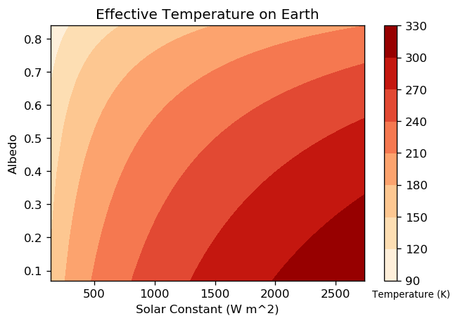

```python
fig, ax = plt.subplots(figsize=(6,4),dpi=120)
cp_T = ax.contourf(X_sol,Y_A,Z_T,cmap=cm.OrRd)

#ax.clabel(cp_T,cp_T.levels,colors='k', fmt='%2.0f',fontsize=8)
cbar = fig.colorbar(cp_T)

ax.set_xlabel('Solar Constant (W m^2)',fontsize=10)
ax.set_ylabel('Albedo',fontsize=10)

ax.set_title ('Effective Temperature on Earth',fontsize=12)
ax.text(2800,0.02,'Temperature (K)',fontsize=8)
```

## Question 3

**Use the MODTRAN model to simulate the terrestrial infrared radiation spectrum at a location on Earth.**

**1. Use the default present-day conditions: CO2=400 ppm; CH4=1.7 ppm; tropospheric ozone=28 ppb; stratospheric ozone scale=1; water vapor scale=1; freon scale=1; temperature offset=0C; no clouds or rain; altitude 70 km; looking down; location: midlatitude winter**

**2.Using the Planck function, plot the blackbody radiation spectra at several different temperatures. Discuss why some of the features in the simulated spectra look like the Plank function at specific temperature**

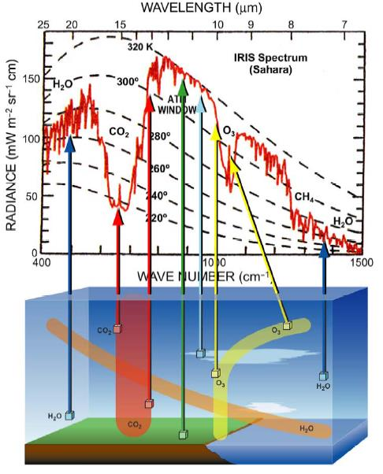

**Answer:** The atmoshpere has different absorptivity regarding to different wavelength. The monochromatic intensity of the radiation at any given wavelength indicates the temperature of the layer of the atmoshphere from which that radiation is emitted (Wallace & Hobbs, 2006). The outmost simulated spectra actually reflects the Earth's emitting radiation at a local surface temperature. At a certain range of wavelength associated with a greenhous gas (GHG) where the spectra looks like the Plank function, it reflects the monochromatic intensity of the upward radiation after absorbing by the GHG within a layer of atmoshpere. The temperature of the fitted curve of the Plank function reveals the temperature of that layer of atmoshpere.

```python
# Open Excel file as Dataframe with Pandas
q1_file = pd.ExcelFile('MetClim/Current_ATM.xlsx')
q3_file = pd.ExcelFile('MetClim/Double_CO2.xlsx')

# Setting an index column
df1 = q1_file.parse('Sheet1', index_col=1)
df2 = q3_file.parse('Sheet1', index_col=1)
```

```python
# Code is obtained from the public sources of ESE315
def blackbody_lam(lam, T):
    """ Blackbody as a function of wavelength (micrometer) and temperature (K).

    returns units of erg/s/cm^2/cm/Steradian = 10^(-7)W/cm^2/cm/Steradian
    Unit: 1 erg = 10^(-7)J
    """
    from scipy.constants import h,k,c
    lam = 1e-6 * lam # convert to metres
    return 2*h*c**2 / (lam**5 * (np.exp(h*c / (lam*k*T)) - 1))
```

```python
# Curve fitting with Plank function
wa = np.linspace(5,30,50)

fit_curv1 = df1.RADIANCE[1:].where((df1.index[1:]>11)& (df1.index[1:]<13)).dropna(how='all')
fit_curv2 = df1.RADIANCE[1:].where((df1.index[1:]>6)& (df1.index[1:]<7)).dropna(how='all')
fit_curv3 = df2.RADIANCE[1:].where((df2.index[1:]>14)& (df2.index[1:]<16)).dropna(how='all')

x1 = fit_curv1.index.values
x2 = fit_curv2.index.values
x3 = fit_curv3.index.values

def func(wa, Tfit):
    return blackbody_lam(wa, Tfit)

popt1, pcov1 = curve_fit(func,df1.index[1:].values,df1['RADIANCE'][1:]*1e10, p0=(200))
popt2, pcov2 = curve_fit(func,x1,fit_curv1*1e10, p0=(200))
popt3, pcov3 = curve_fit(func,x2,fit_curv2*1e10, p0=(200))
popt4, pcov4 = curve_fit(func,x3,fit_curv3*1e10, p0=(200))

fit1 = blackbody_lam(wa,popt1)
fit2 = blackbody_lam(wa,popt2)
fit3 = blackbody_lam(wa,popt3)
fit4 = blackbody_lam(wa,popt4)
```

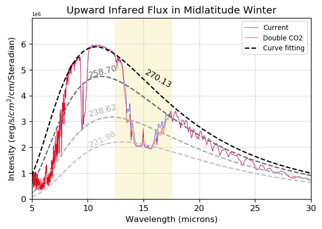

```python
wa = np.linspace(5,30,50)
fig, ax = plt.subplots(figsize=(6,4),dpi=120)

ax.plot(df1.index[1:],df1['RADIANCE'][1:]*1e10,lw=0.4,color='b')
ax.plot(df2.index[1:],df2['RADIANCE'][1:]*1e10,lw=0.4,color='r')

ax.plot(wa,fit2,'--',color='k')
ax.plot(wa,fit1,'--',color='dimgrey')
ax.plot(wa,fit3,'--',color='darkgrey')
ax.plot(wa,fit4,'--',color='silver')

ax.text(15,4.3e6,'%.2f'%popt2,color='k',rotation=-30)
ax.text(10,4.7e6,'%.2f'%popt1,color='dimgrey',rotation=15)
ax.text(10,3.2e6,'%.2f'%popt3,color='darkgrey',rotation=15)
ax.text(10,2e6,  '%.2f'%popt4,color='silver',rotation=25)

ax.set_xlim(5,30)
ax.set_ylim(0,7e6)
ax.set_yticks([0,1e6,2e6,3e6,4e6,5e6,6e6])
ax.set_yticklabels([0,1,2,3,4,5,6])

ax.fill_betweenx(np.linspace(0,7e6),12.5,17.5,color='khaki',alpha=0.3)

ax.text(5,7.1e6,'1e6',fontsize=6)
ax.set_xlabel('Wavelength (microns)')
ax.set_ylabel('Intensity (erg/s/$cm^2$/cm/Steradian)')
ax.set_title('Upward Infared Flux in Midlatitude Winter')
ax.legend(['Current','Double CO2','Curve fitting'],fontsize=8)
ax.grid(lw=0.3)
```

**3. Increase the concentration of one of the greenhouse gases. Plot both the old and the new simulated spectra in one plot. Calculate and plot the difference between the two spectra. Discuss how they are related to the changes you made to the greenhouse gases.**

Double CO2 concentation: CO2=800 ppm; CH4=1.7 ppm; tropospheric ozone=28 ppb; stratospheric ozone scale=1; water vapor scale=1; freon scale=1; temperature offset=0C; no clouds or rain; altitude 70 km; looking down; location: midlatitude winter

When double the CO2 concentration to 800 ppm, the upward IR flux represents an apparent decreasing at the range of wavelength of around 13-16 microns. CO2 and other greenhouse gases (GHGs) act to absorb infared radiation, which associates with the negative peak in the spectra. This phenomenon is consistent with the fact that increasing the concentration of GHGs have a positive radiative forcing. When the concentration of CO2 is added from 400 ppm to 800 ppm, the radiative forcing is $(231.575-229.251)= 2.32 W/m^2$.

# Extra credit

## Question 4

**1. Compare CO2 vs. methane as greenhouse gases. Which would be the stronger if they had the same concentrations?**

(1) Getting the initial plot: keep other conditions unchanged, setting the CO2 and CH4 to be 0 ppm. Tropospheric ozone=28 ppb; stratospheric ozone scale=1; water vapor scale=1; freon scale=1; temperature offset=0C; no clouds or rain; altitude 70 km; looking down; location: midlatitude winter

(2) When setting either the CO2 or CH4 to 400 ppm and keeping others unchanged, CO2 is stronger than CH4. The radiative forcing caused by CO2 is 20.91 $W/m^2$, while the radiative forcing is 9.58 $W/m^2$ for CH4.  
This could also be confirmed according to the upward IR spectra as shown bellow.

```python
# Open Excel file as Dataframe with Pandas
data = []
for file in ['MetClim/Extra_initial.xlsx','MetClim/Extra_CO2.xlsx','MetClim/Extra_CH4.xlsx']:
    data.append(pd.ExcelFile(file).parse('Sheet1',index_col=0))
```

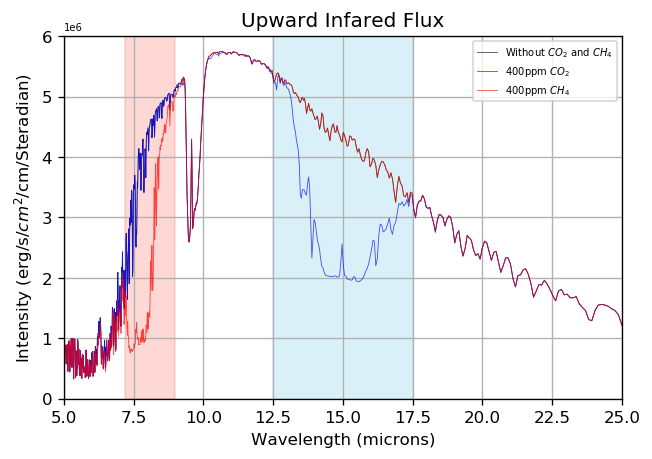

```python
fig,ax = plt.subplots(figsize=(6,4),dpi=120)
colors=['k','b','r']
for i in range(3):
    ax.plot(data[i].index,data[i]['RADIANCE']*1e10,color=colors[i],lw=0.5,alpha=0.7)
ax.set_xlim(5,25)
ax.set_ylim(0,6e6)
ax.set_yticks([0,1e6,2e6,3e6,4e6,5e6,6e6])
ax.set_yticklabels([0,1,2,3,4,5,6])

ax.fill_betweenx(np.linspace(0,7e6),12.5,17.5,color='skyblue',alpha=0.3)
ax.fill_betweenx(np.linspace(0,7e6),7.2,9,color='salmon',alpha=0.3)

ax.text(5,6.1e6,'1e6',fontsize=6)
ax.set_xlabel('Wavelength (microns)')
ax.set_ylabel('Intensity (erg/s/$cm^2$/cm/Steradian)')
ax.set_title('Upward Infared Flux')
ax.legend(['Without $CO_2$ and $CH_4$','400ppm $CO_2$','400ppm $CH_4$'],fontsize=6)
ax.grid()
```

**Which is stronger given their current concentrations? Explain this phenomenon.**

(3) Given current concentrations that CO2 is 400 ppm and the methane is 1.7 ppm in the atmoshpere, when increasing 1 ppm of CO2, the radiative forcing is only 0.03 $W/m^2$. The radiative forcing caused by increasing 1 ppm of methane is 0.34 $W/m^2$. The change of upward infared flux is more sensitive to the addition of methane.

Explanation:

When CO2 and methane have the same concentration, CO2 shows a strong absorptivity in a wider range of wavelength, meanwhile, methane only appears a evident absorptivity in around 7.5-8 microns. In this situation, the CO2 is stronger than methane.

In the current situation, the CO2 is much more abundant than methane in the atmosphere.Considering the absorption band of methan is almost not overlapped with other GHGs, while CO2 and water vapor overlap somewhere. When adding a small amount of methane, it will contribute more radiation to be absorbed. But increasing a relative small amount of CO2 will not bring too much change to the upward infared intensity.